# Homework 3

## 1. Using Github

The repository can be accessed at https://ct18173.github.io/homework3/.

## 2. Stroop, Standing Up or Sitting Down

### Loading in the Stroop data.

```r
stroopdata <- read.csv('stroop_standing_data.csv')
```

### I am cleaning the data by first removing the mistrials and incorrect trials, and then removing the practice phase trials. Then, I removed the baseline data. Then I changed the data type for rt from character to numeric.

```r
stroopdataclean <- stroopdata %>%
  select(subject, age, gender, condition, phase, trial, stimulus, congruency, rt, correct) %>%
  drop_na() %>%
  filter(correct != 999) %>%
  filter(correct != 0) %>%
  filter(phase != 'practice') %>%
  filter(congruency != 'baseline') %>%
  mutate(rt = as.numeric(rt))
```

### Summarising the data to create a mean reaction time to see how this the reaction time differed across different phases (sitting vs standing) and congruency (congruent vs incongruent).

```r
stroopdataclean <- group_by(stroopdataclean, subject, congruency, phase)
stroopdataclean <- summarise(stroopdataclean, mean_rt = mean(rt))
```

### Pivoting the data so that congruent and incongruent data from each subject can be easily compared.

```r
stroopdataclean <- pivot_wider(stroopdataclean, names_from = congruency, values_from = 'mean_rt')
head(stroopdataclean)
```

```
## # A tibble: 6 x 4
## # Groups:   subject [3]
##   subject phase    congruent incongruent
##     <int> <chr>        <dbl>       <dbl>
## 1       1 sitting      1106.       1155.
## 2       1 standing      922.        955.
## 3       2 sitting       904.       1038.
## 4       2 standing      882.       1074.
## 5       3 sitting       892.       1082.
## 6       3 standing      777.        975.
```

### Adding a new variable which calculates ‘Stroop Effect’ which is the difference between the incongruent and congruent conditions.

```r
stroopdataclean <- mutate(stroopdataclean, stroopeffect = incongruent-congruent)
head(stroopdataclean)
```

```
## # A tibble: 6 x 5
## # Groups:   subject [3]
##   subject phase    congruent incongruent stroopeffect
##     <int> <chr>        <dbl>       <dbl>        <dbl>
## 1       1 sitting      1106.       1155.         48.5
## 2       1 standing      922.        955.         33.0
## 3       2 sitting       904.       1038.        135.
## 4       2 standing      882.       1074.        192.
## 5       3 sitting       892.       1082.        190.
## 6       3 standing      777.        975.        199.
```

### Fitting a mixed effects model to the data. Subject is the random effect.

```r
stroopdatamodel <- lmer(stroopeffect ~ phase + (1|subject), stroopdataclean)
summary(stroopdatamodel)
```

```
## Linear mixed model fit by REML ['lmerMod']
## Formula: stroopeffect ~ phase + (1 | subject)
##    Data: stroopdataclean
##
## REML criterion at convergence: 2627.7
##
## Scaled residuals:
##      Min       1Q   Median       3Q      Max
## -2.04984 -0.52378 -0.03226  0.49823  2.65248
##
## Random effects:
##  Groups   Name        Variance Std.Dev.
##  subject  (Intercept) 2765     52.58
##  Residual             1819     42.65
## Number of obs: 239, groups:  subject, 122
##
## Fixed effects:
##               Estimate Std. Error t value
## (Intercept)    115.300      6.179   18.66
## phasestanding   17.046      5.553    3.07
##
## Correlation of Fixed Effects:
##             (Intr)
## phasestndng -0.452
```

### Creating a box plot to show the data.

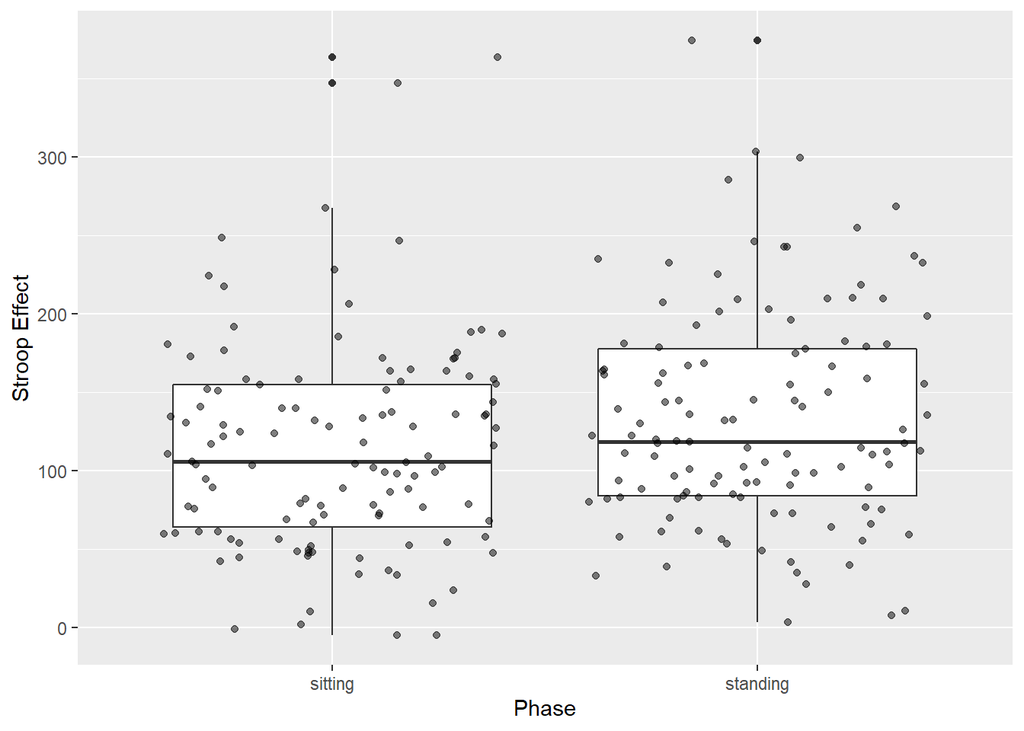

### This study found the opposite to what the original Stroop experiment showed. This experiment found that participants showed a slightly smaller Stroop effect when sitting. This result was significant, but not to a large extent as the t-value is still very small which indicates less difference between the conditions.

## 3. The Dimensions of Popular Music

### Loading in the Spotify data.

```r
spotifydata <- read.csv('spotify_cleaned.csv')
```

### I removed the data that related to things other than the components I wanted to look at in the data. Then I conducted a PCA on the data.

```r
pcaspotifydata <- select(spotifydata, -X, -Track.Name, -Artist, -Streams, -time_signature)
pcaspotifydata <- prcomp(pcaspotifydata)
summary(pcaspotifydata)
```

```
## Importance of components:
##                            PC1     PC2     PC3    PC4     PC5     PC6     PC7
## Standard deviation     38.6494 28.8325 3.74060 1.9357 0.46579 0.20839 0.18091
## Proportion of Variance  0.6375  0.3548 0.00597 0.0016 0.00009 0.00002 0.00001
## Cumulative Proportion   0.6375  0.9923 0.99826 0.9999 0.99995 0.99997 0.99998
##                            PC8   PC9    PC10    PC11    PC12
## Standard deviation     0.11927 0.104 0.09086 0.07812 0.01857
## Proportion of Variance 0.00001 0.000 0.00000 0.00000 0.00000
## Cumulative Proportion  0.99999 1.000 1.00000 1.00000 1.00000
```

### This data replicates the previous PCA results as I have found that the first two principal components also account for 99% of the variance. This can also been shown in the Scree plot below.

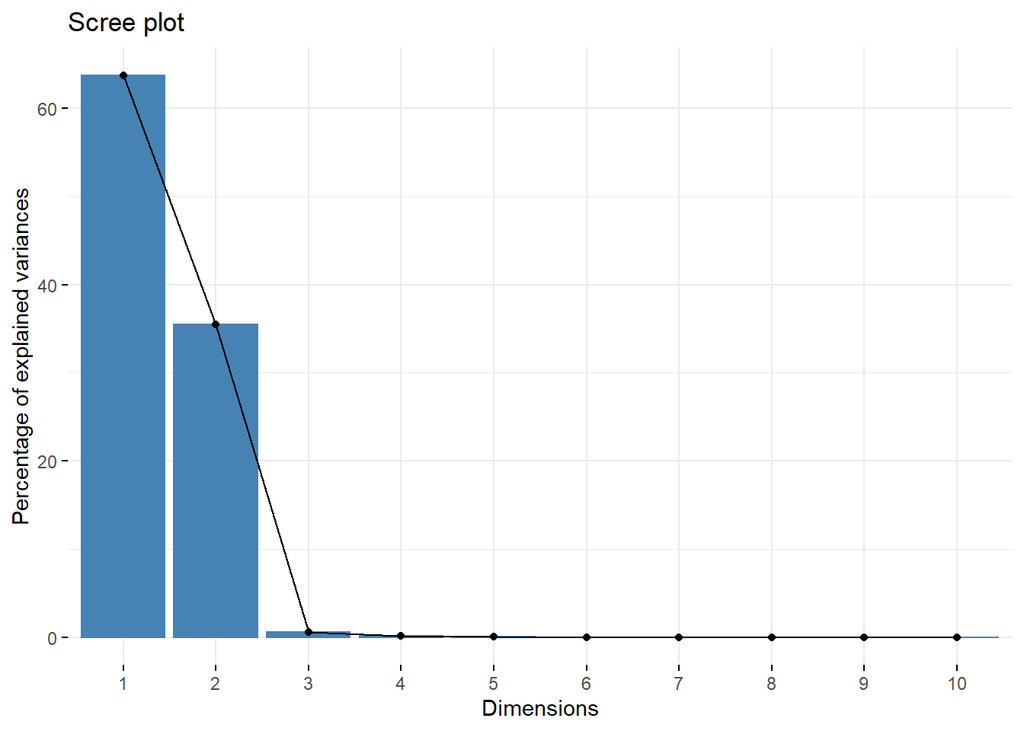

### From the findings I interpret that the first two prinicple components contribute the most to the variance in pop music. Principle components 3-8 have a very very small amount of contribution to the variance, and principle components 9-12 have no contribution.

### The plot below shows that tempo and duration are the main contributing factors to the variance in pop music. This plot is an improvement of the plot shwon in the article as you can see clearer here that both components 1 and 2 are orthoganal, and therefore uncorrelated. This is less clear in the scatter plot.

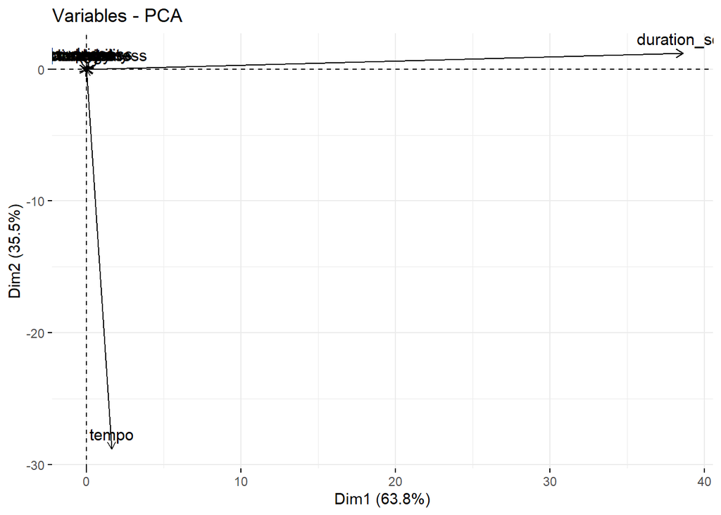

```r
pcaplot <- fviz_pca_var(pcaspotifydata)
pcaplot
```

### These two plots show that duration makes up almost 100% of principal component 1 and tempo almost 100% of prinicpal component two.

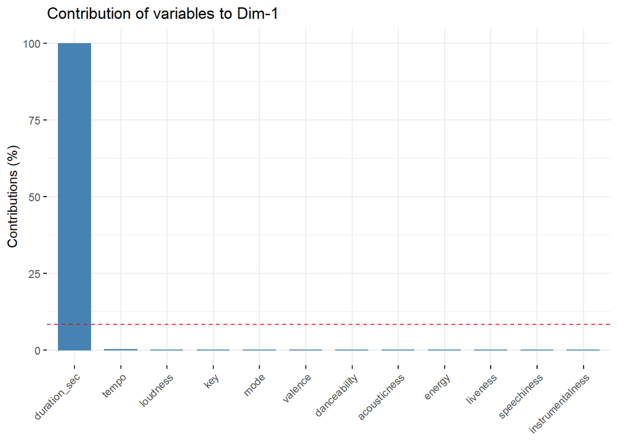

```r
contrib1 <- fviz_contrib(pcaspotifydata, choice="var", axes = 1)
contrib1
```

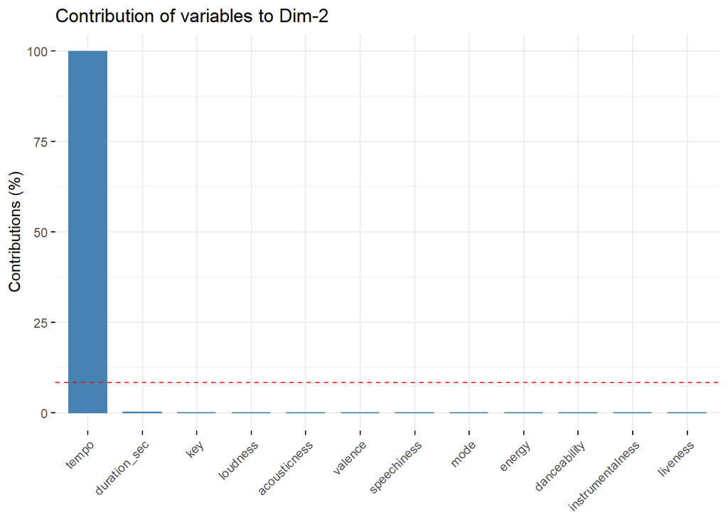

```r
contrib2 <- fviz_contrib(pcaspotifydata, choice="var", axes = 2)
contrib2
```

### My conclusion is that most of the variance in pop music can be explained by song duration and tempo. This means that the pop music analysed probably sounds very similar as the other dimensions did not explain much of the variance.